# Computer Test

STAT5003 Semester 2, 2020

14th October, 2020

### Question 1

Consider the number of covid cases in both NSW and VIC since January 25th up to October 7th. The data has been simplifed with date variables stripped off and saved into a `rds` file that contains case counts in two columns for NSW and VIC respectively. The data can be loaded with the following command.

```r
covid <- readRDS("covid-data.rds")
```

Using this data, answer the following questions.

1. [**2 marks**] Inspect the structure of the `covid` data using the `str` command and determine the class of the `covid` variable in `R`, along with its dimension.

   ```r
   # Input your answer here
   ```

   **Solution**:

   ```r
   str(covid)
   ```

   ```
   ## 'data.frame':    257 obs. of  2 variables:
   ##  $ NSW: int  0 3 1 0 0 0 0 0 0 0 ...
   ##  $ VIC: int  1 0 0 0 2 0 0 1 0 0 ...
   ```

   A `data.frame` with with 257 cases and two variable
2. [**2 marks**] Add an extra column to the `covid` object called `NSW_and_VIC` that contains the number of cases for both NSW and VIC. Demonstrate that it has been added using the `head` command.

   ```r
   # Input your answer here
   ```

   **Solution**:

   ```r
   # Both below are equivalent. Other ways possible
   covid <- transform(covid, NSW_and_VIC = NSW + VIC)
   head(covid)
   ```

   ```
   ##   NSW VIC NSW_and_VIC
   ## 1   0   1           1
   ## 2   3   0           3
   ## 3   1   0           1
   ## 4   0   0           0
   ## 5   0   2           2
   ## 6   0   0           0
   ```

3. [**3 marks**] Plot the data including the aggregated count for both NSW and VIC computed in the previous part on the same plot with a line chart with different colours for each column. (You should produce a single plot with three lines, one for each column. Your plot should have appropriate axis labels and ideally a legend to identify what each line represents) **Solution**:

   ```r
   # Input your answer here
   ```

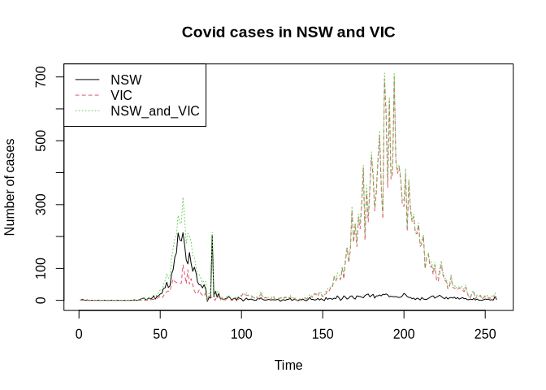

   ```r
   # ggplot also possible but requires data reshaping
   matplot(covid, ty = 'l', xlab = "Time", ylab = "Number of cases", main = "Covid cases in NSW and VIC")
   legend("topleft", legend = colnames(covid), col = 1:3, lty = 1:3)
   # ggplot version
   library(ggplot2)
   ```

   ```r
   melted.data <- reshape2::melt(covid) |> transform(index = seq(nrow(covid)))
   ```

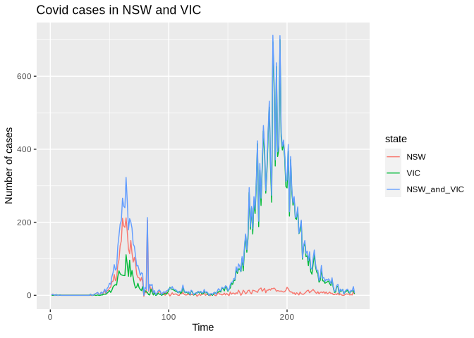

   ```r
   names(melted.data) <- c("state", "count", 'time')
   ggplot(melted.data, aes(x = time, y = count, colour = state)) +
       geom_line() + xlab("Time") + ylab("Number of cases") +
       ggtitle("Covid cases in NSW and VIC")
   ```

4. [**2 marks**] Add a smoother to the plot for the combined cases of NSW and VIC only (only one smoother for the aggregate count, not separate ones for NSW or VIC). You will need to try a few numbers to find an appropriate bandwidth. **Solution**:

   ```r
   # Input your answer here
   ```

[figure not shown]

   ```r
   # ggplot also possible but requires data reshaping
   matplot(covid, ty = 'l', xlab = "Time", ylab = "Number of cases", main = "Covid cases in NSW and VIC")
   lines(lowess(covid[[3]], f = 0.025), col="blue")
   legend("topleft", legend = c(colnames(covid), "Smoother of NSW and VIC"), col = c(1:3, "blue"), lty = c(1:3, 1))
   ```

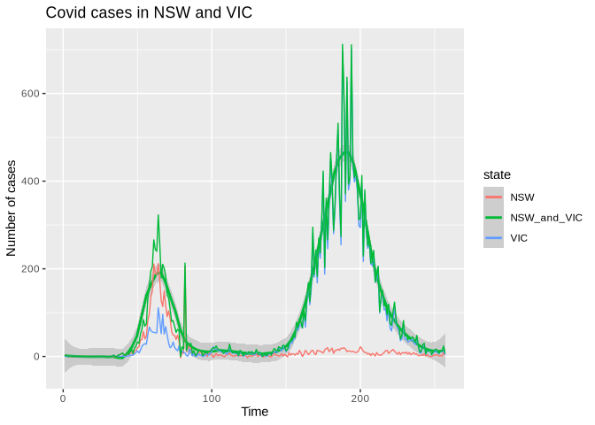

   ```r
   # Using ggplot2
   ggplot(melted.data, aes(x = time, y = count, colour = state)) +
       geom_smooth(span = 0.2, data = melted.data |> subset(state == "NSW_and_VIC"), aes(x = time, y = count)) +
       geom_line() + xlab("Time") + ylab("Number of cases") +
       ggtitle("Covid cases in NSW and VIC")
   ```

### Question 2

Construct and analyze a binary classifier from a simulated dataset using your SID and the `mlbench` package.

1. [**4 marks**] Simulate a single dataset of `n = 500` observations completing the code below replacing `<insert SID here>` with your SID respectively. Inspect the `q2.dat` using the `head` command and verify the dimension of the `data.frame` and that there are 2 numeric features and a single factor variable of class labels. **Note**: *You should explicitly verify the data type is numeric or factor or inspect the class of each column*.

   ```r
   library(mlbench)
   SID <- <insert SID here># INSERT YOUR SID AS AN INTEGER HERE
   set.seed(SID)
   simulated.data <- mlbench.2dnormals(n = 500, sd = 2)
   q2.dat <- as.data.frame(simulated.data)
   ```

   **Solution**:

   ```r
   library(mlbench)
   set.seed(12345678)
   simulated.data <- mlbench.2dnormals(n = 500, sd = 2)
   q2.dat <- as.data.frame(simulated.data)
   head(q2.dat)
   ```

   ```
   ##          x.1        x.2 classes
   ## 1  1.0172800  1.1517268       1
   ## 2 -1.0376059  1.9488430       1
   ## 3  0.1335094  1.2782187       1
   ## 4  3.3210152 -0.6242699       2
   ## 5  4.1621537  5.1454825       1
   ## 6 -0.5101281 -0.2144875       1
   ```

   ```r
   dim(q2.dat)
   ```

   ```
   ## [1] 500   3
   ```

   ```r
   # Any of the below are acceptable
   lapply(q2.dat, class)
   ```

   ```
   ## $x.1
   ## [1] "numeric"
   ##
   ## $x.2
   ## [1] "numeric"
   ##
   ## $classes
   ## [1] "factor"
   ```

   ```r
   str(q2.dat)
   ```

   ```
   ## 'data.frame':    500 obs. of  3 variables:
   ##  $ x.1    : num  1.017 -1.038 0.134 3.321 4.162 ...
   ##  $ x.2    : num  1.152 1.949 1.278 -0.624 5.145 ...
   ##  $ classes: Factor w/ 2 levels "1","2": 1 1 1 2 1 1 2 2 2 1 ...
   ```

2. [**5 marks**] Assuming 1 is the negative class and 2 is the positive class, train a **logistic regression model** using the entire dataset. Inspect the `summary` output and comment on whether the features are useful for this logistic regression model. Also compute the accuracy and F1 score of this logistic regression model among the training data using only the predicted and observed values (i.e. not using the `caret::confusionMatrix` function or any other equivalent helper function from another package).

   **Solution**:

   ```r
   full.logit.model <- glm(classes ~ ., data = q2.dat, family = binomial(link = "logit"))
   summary(full.logit.model)
   ```

   ```
   ##
   ## Call:
   ## glm(formula = classes ~ ., family = binomial(link = "logit"),
   ##     data = q2.dat)
   ##
   ## Deviance Residuals:
   ##     Min       1Q   Median       3Q      Max
   ## -2.1427  -0.8571   0.0154   0.7796   3.2339
   ##
   ## Coefficients:
   ##             Estimate Std. Error z value Pr(>|z|)
   ## (Intercept)  0.07634    0.11015   0.693    0.488
   ## x.1         -0.53801    0.06143  -8.758  < 2e-16 ***
   ## x.2         -0.43508    0.05740  -7.580 3.45e-14 ***
   ## ---
   ## Signif. codes:  0 '***' 0.001 '**' 0.01 '*' 0.05 '.' 0.1 ' ' 1
   ##
   ## (Dispersion parameter for binomial family taken to be 1)
   ##
   ##     Null deviance: 693.15  on 499  degrees of freedom
   ## Residual deviance: 499.95  on 497  degrees of freedom
   ## AIC: 505.95
   ##
   ## Number of Fisher Scoring iterations: 5
   ```

   ```r
   log.predictions <- predict(full.logit.model, newdata = q2.dat, type = "response")
   predictions <- ifelse(log.predictions > 0.5, 2, 1)
   accuracy <- mean(predictions == q2.dat$classes)
   accuracy
   ```

   ```
   ## [1] 0.774
   ```

   ```r
   cM <- xtabs(~ predictions + q2.dat$classes)
   TP <- cM[2, 2]
   FP <- cM[2, 1]
   FN <- cM[1, 2]
   F1 <- 2 * TP/(2  * TP + FN + FP)
   F1
   ```

   ```
   ## [1] 0.7735471
   ```

3. [**2 marks**] Using the trained model computed in part b. Compute and draw the decision boundary on a plot. Below is the code to produce the required scatterplot coloured by the two binary class labels.

   ```r
   plot(x.2 ~ x.1, data = q2.dat, col = classes)
   ```

   **Solution**:

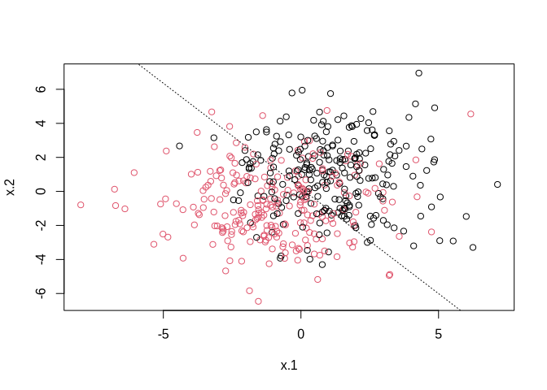

   ```r
   plot(x.2 ~ x.1, data = q2.dat, col = classes)
   betas <- coef(full.logit.model)
   abline(a = -betas[1]/betas[3], b = -betas[2]/betas[3], lty = "dotted")
   ```

4. [**6 marks**] Implement a 5-fold cross-validation (CV) procedure to calculate the average F1 score on each of the 5 folds using **Logistic Regression**. Write your own code for this question. That is, do not use any functions from other packages such as `caret`. However, you may use `caret` to create the folds and also compute the F1 score within each fold via `confusionMatrix` for this part. Use the `set.seed(5003)` line to ensure you get the same output on each run.

   ```r
   set.seed(5003)
   ```

   **Solution**:

   ```r
   set.seed(5003)
   library(caret)
   fold <- createFolds(q2.dat$classes, k = 5)
   test.fold.sizes <- vapply(fold, length, numeric(1))
   # For convenience, put the 5 fold CV sets into a list
   split.data.into.folds <- function(x, dat, n = nrow(dat)) {
       which.group = factor(ifelse(seq(n) %in% x, "Test", "Training"))
       split(dat, which.group)
   }
   training.test <- lapply(fold, split.data.into.folds, dat = q2.dat, n = nrow(q2.dat))
   fitted.log.models <- function(x, k = 5, label.name = "classes") {
       log.model <- glm(classes ~ ., data = x$Training, family = binomial(link = "logit"))
       predicted <- factor(unname(ifelse(predict(log.model, newdata = x$Test) > 0.5, 2, 1)))
       observed <- x$Test[[label.name]]
       list(predicted = predicted, observed = observed)
   }
   log.output <- lapply(training.test, fitted.log.models)
   accuracy.within <- vapply(log.output, function(x) mean(x$observed == x$predicted), numeric(1))
   accuracy.within
   ```

   ```
   ## Fold1 Fold2 Fold3 Fold4 Fold5
   ##  0.77  0.74  0.78  0.76  0.72
   ```

   ```r
   mean(accuracy.within)
   ```

   ```
   ## [1] 0.754
   ```

   ```r
   f1.within <- vapply(log.output, function(x) {
     cM <- caret::confusionMatrix(x$predicted, x$observed, positive = "2")
     cM[["byClass"]][["F1"]]
   }, numeric(1))
   f1.within
   ```

   ```
   ##     Fold1     Fold2     Fold3     Fold4     Fold5
   ## 0.7526882 0.6666667 0.7708333 0.7391304 0.6500000
   ```

   ```r
   mean(f1.within)
   ```

   ```
   ## [1] 0.7158637
   ```

### Question 3

The standard multiple regression model with two features assumes that the response and features follow the model
$$Y_i = \beta_0 + \beta_1 X_1 + \beta_2 X_2 + \varepsilon \qquad \varepsilon \sim \mathcal N(0, \sigma^2).$$
This can lead to the likelihood model (you do not need to show this) where the log likelihood of the parameters $\boldsymbol{\theta} = \left( \beta_0, \beta_1, \beta_2, \sigma\right)$ is given by
$$\mathcal L(\boldsymbol{\theta}|\mathcal X) = \begin{cases} -\infty, & \qquad \text{if } \sigma < 0;\\
-\frac{n}{2}\log(2 \pi) - n\log (\sigma) - \frac{1}{2\sigma^2} \sum_{i = 1}^n (Y_i - \beta_0 - \beta_1 X_{1i} - \beta_2X_{2i})^2, & \qquad \text{otherwise}.\end{cases}$$
where $\mathcal X = (Y_1, \ldots, Y_n, X_{11}, \ldots, X_{1n}, X_{21}, \ldots, X_{2n})$

For this question consider estimating a linear model using both the standard least squares fitting procedure using `lm` and an approach using the method of Maximum Likelihood Estimation (MLE). In particular, consider the `BostonHousing` data available in the `mlbench` package with the median value of the housing as the response (`medv`) and the predictors being the number of rooms (`rm`) and the percentage of lower status of the population (`lstat`) respectively. It can be loaded using the code below

```
data(BostonHousing, package = "mlbench")
q3.dat <- subset(BostonHousing, select = c("medv", "lstat", "rm"))
```

1. [**2 marks**] Inspect the `q3.dat` data, determining the dimension of the data and produce a matrix scatterplot (using the function `pairs` or other equivalent function).

   **Solution**:

   ```r
   data(BostonHousing, package = "mlbench")
   q3.dat <- subset(BostonHousing, select = c("medv", "lstat", "rm"))
   dim(q3.dat)
   ```

   ```
   ## [1] 506   3
   ```

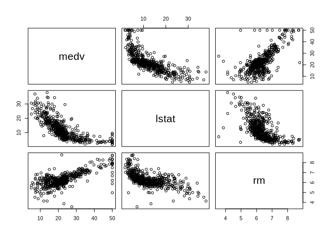

   ```r
   pairs(q3.dat)
   ```

2. [**2 marks**] Fit the linear regression using the `lm` function in `R` and extract the regression coefficients (the $\beta$ values) and the estimate of $\sigma$.

   **Solution**:

   ```r
   simple.lm <- lm(medv ~ rm + lstat, data = q3.dat)
   lm.coefs <- coef(simple.lm)
   lm.sigma <- sigma(simple.lm)
   lm.estimates <- c(lm.coefs, lm.sigma)
   lm.estimates
   ```

   ```
   ## (Intercept)          rm       lstat
   ##  -1.3582728   5.0947880  -0.6423583   5.5402574
   ```

3. [**3 marks**] Define a function in `R` that computes the *negative* log-likelihood as a function of $\boldsymbol{\theta}$ defined above. (Note $\boldsymbol{\theta} = (\beta_0, \beta_1, \beta_2, \sigma)$ has 4 elements and will require a function with four input arguments e.g. `fun <- function(w, x, y, z)` has four arguments `w, x, y, z`) **Solution**:

   ```r
   n <- nrow(q3.dat)
   y <- q3.dat[["medv"]]
   x1 <- q3.dat[["rm"]]
   x2 <- q3.dat[["lstat"]]
   negLogLikelihood <- function(beta0 = 0, beta1 = 0, beta2 = 0, sigma = 1) {
       if (sigma < 0)
         return(Inf)
       else
          out <- n/2 * log(2 * pi) + n * log(sigma) + 1/(2 * sigma^2) * sum((y - beta0 - beta1 * x1 - beta2 * x2)^2)
       out
   }
   ```

4. [**2 marks**] As an alternative algorithm to estimate the regression coefficients and $\sigma$, use the `q3.dat` data to compute the MLE of $\boldsymbol{\theta}$ using the using the `stats4::mle` function (i.e. the function `mle` in the `stats4` package) or via a grid search if you prefer. **Solution**:

   ```r
   theta.mle <- stats4::mle(minuslogl = negLogLikelihood)
   theta.mle <- theta.mle@coef
   theta.mle
   ```

   ```
   ##     beta0     beta1     beta2     sigma
   ## -1.258765  5.086072 -0.645697  5.517570
   ```

5. [**2 marks**] Compare the outputs generated from `lm` and the MLE method above and comment. **Solution**:

   ```r
   theta.lm <- c(coef(simple.lm), sigma(simple.lm))
   theta.lm - theta.mle
   ```

   ```
   ##  (Intercept)           rm        lstat
   ## -0.099507973  0.008715838  0.003338656  0.022687351
   ```

   The outputs for the `lm` method and `MLE` are close and give similar results. The biggest discrepancy in the intercept estimate but that is the one with the largest standard error in the regression method.